# An open source framework for end-to-end re-forecast studies in GSI-WRF-MET

### Thanks to

##### Colin Grudzien, Minghua Zheng, Caroline Papadopoulos, Rachel Weihs, Dan Steinhoff, Jennifer Haase, Luca Delle Monache, Ivette Hernández Baños, Matthew Simpson, Pat Mulrooney, Brian Kawzenuk, Christopher Harrop, Marty Ralph, Julie Kalansky, CW3E’s Management and Administration Team, CW3E’s AR-Recon Team, West-WRF Team, NRT Team and Forecast Verification Team et al. for making this work possible

## Data assimilation (DA) as a workflow process

- CW3E currently has an **operational near-real-time (NRT) ensemble forecast / machine learning prediction system**, and has been developing an **experimental DA re-forecast system** based on this.
- **DA** is a **notoriously complex operational problem**, which involves **interdependent steps** of:
- **procuring**;
- **pre-processing**;
- **generating**; and
- **post-processing**;
- **large volumes of numerical weather prediction (NWP) data**.
- In order to **scale to operation**, DA typically requires the use of a **workflow manager to interface between the user’s tasks and the super computer’s job scheduler**.
- From **Christopher Harrop (creator of Rocoto)**:

> **Workflow Management** is a concept that originated in the 1970’s to handle business process management… to manage complex collections of business processes that need to be carried out in a certain way with **complex interdependencies and requirements**…

> …scientific workflows are driven by the **scientific data that “flows” through them**… usually triggered by the availability of some kind of input data, and a task’s result is usually… **fed as input to another task in the workflow**.

### Data assimilation in a GSI-WRF-MET Stack

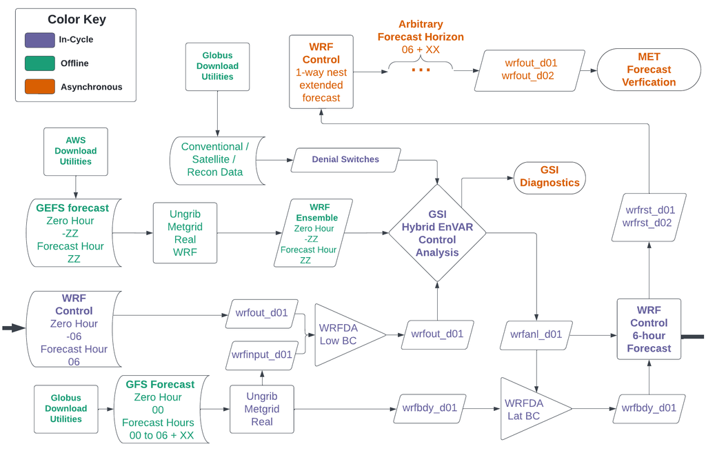

- This is automated in an [**end-to-end data assimilation cycling system**](https://github.com/CW3E/GSI-WRF-Cycling-Template) in the **GSI-WRF-MET stack** using [**Rocoto**](https://christopherwharrop.github.io/rocoto/).
- This builds on **CW3E’s AR-Recon experiments, and the NRT and Verification Teams' workflows**.

## CW3E’s Open Source Institutional Code Base

[figure not shown]

- These code repositories are available on the [**CW3E Github**](https://github.com/CW3E).
- Code is **licensed for reuse, redistribution and modification** under the **Apache 2.0 Open Source License**.
- This is a **permissive license** that has conditions familiar to an **academic environment**:
- **original authors are given attribution**; and
- **redistributed code includes change logs**.
- **Derived products do not need to be made open source**;
- this can be **reused for nearly any purpose** by downstream users.
- This makes these codes suitable for **controlled information environments**, while still **benefiting from community interaction**.

### Data assimilation in a GSI-WRF-MET Stack

- This uses a **Bash / Python data science stack**, including an [**IPython API**](https://github.com/CW3E/GSI-WRF-Cycling-Template/blob/main/rocoto_utilities.py).
- This is designed to **enable easy looping** of:
- **valid dates**,
- **task indices**,
- **control flows**, and
- **case studies**,
- as demonstrated to the right:

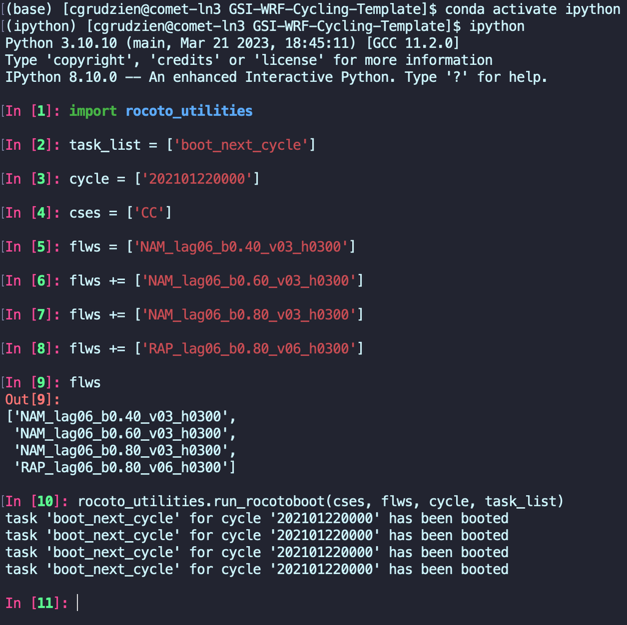

- NOTE: there is **no documentation (outside of comments)**;
- a new version will be released ASAP, built on the [**Cylc workflow system**](https://cylc.github.io/).
- **Conversion to Cylc** is necessary for:
- **long-term support**, and for
- a unified system for **formally “equivalent” experiments in GSI-WRF and JEDI-MPAS** with verification performed on **common metrics in MET**.
- This intends to build on the open source [**JEDI-MPAS workflow templates**](https://github.com/NCAR/MPAS-Workflow) developed at NCAR.

### Data assimilation in a GSI-WRF-MET Stack

- **Experiment settings** are currently **configured using an XML file** to instruct Rocoto as below:

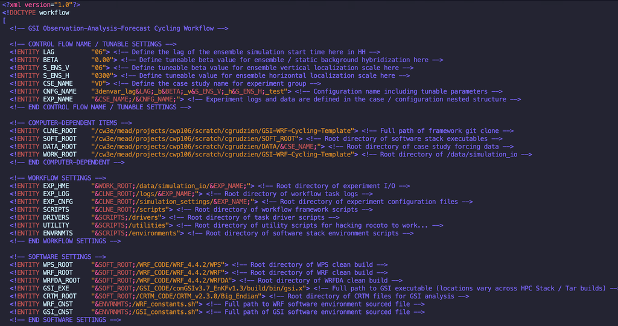

- However, this will be **replaced with an analogous YAML file** for the **Cylc re-write**.

### Data assimilation in a GSI-WRF-MET Stack

- In the **Rocoto logs**, this workflow is presented in **cycle order** as in the following:

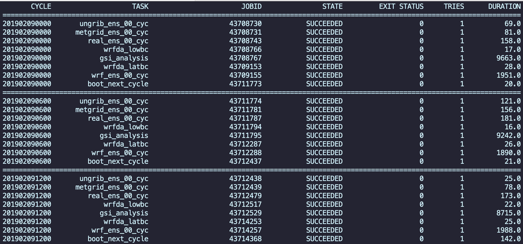

### Data assimilation in a GSI-WRF-MET Stack

- This currently allows the **mixing of asynchronous jobs in heterogeneous cycles**, with specific settings **depending on the forecast zero-hour**.

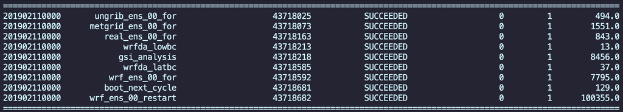

- For a **verification at a specified valid date** of 2019-02-15_00_00, the above cycle needs a **4-day forecast**.
- However, the following cycle will only require a **3-day forecast**.

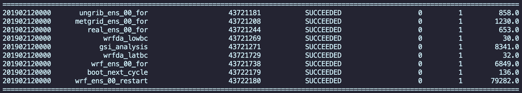

- For **offline, re-forecast studies**, this allows significant **performance optimization of the workflow**, eliminating the need to call unnecessary resources.

## MET Verification of 2022-2023 AR Season

- **MET forecast verification** is a key aspect of this workflow used to **objectively assess forecast skill**.
- We shift focus now to the [**MET verification tools**](https://github.com/CW3E/MET-tools) in this workflow with the **2022 - 2023 AR Season** as a **highly applicable use-case** for these codes.
- This is a perfect example of where one needs to **analyze data from multiple**:
  - **valid dates**;
  - **forecast leads**;
  - **models**; and
  - **sub-domains**.
- **Batch processing** all this data is a non-trivial task, as a workflow should:
  - **handle maps of hyper-parameter configurations**,
  - **systematically organize outputs**,
  - be **robust to missing data** in the workflow stream,
  - perform **error checks and exception handling**,
  - generate **traceable logs for debugging**,
  - **automate plotting axes / labels / legends**, and
  - require **minimal hard-coded configurations**.
- This problem arises frequently with **tuning the GSI-WRF-Cycling-Template**.

## Multidate / Multilead Heatplot Templates

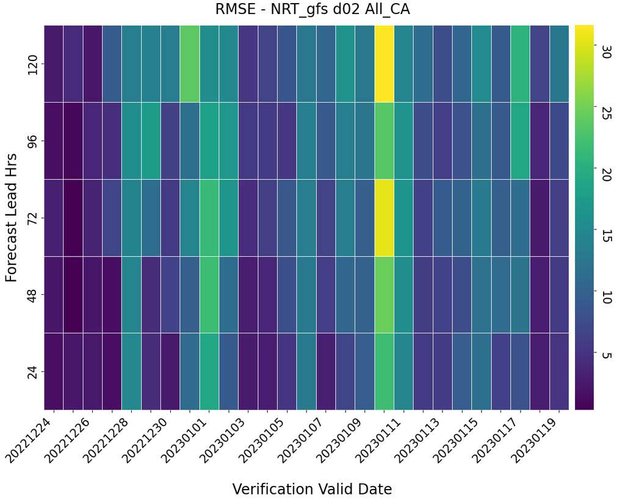

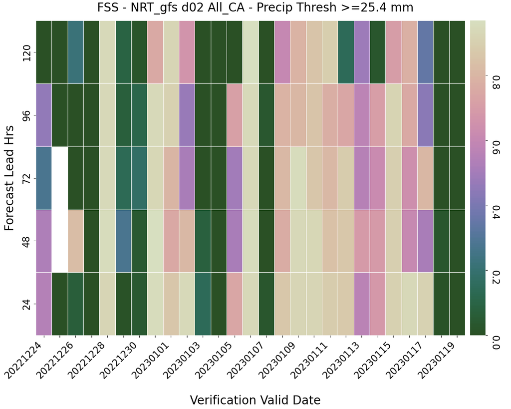

- **Grid-Stat outputs** are parsed, filtered and converted into [**Pandas dataframes for plotting and diagnostics**](https://pandas.pydata.org/).
- Templates are designed for **multidate / multilead heatplots** for diagnostics over **ranges of valid dates**.
- **Missing / erroneous data** is **filtered by the workflow post-processing routines**.

### Multi-lead Lineplot Templates

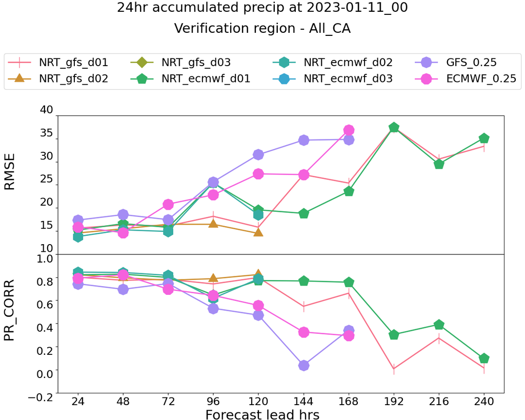

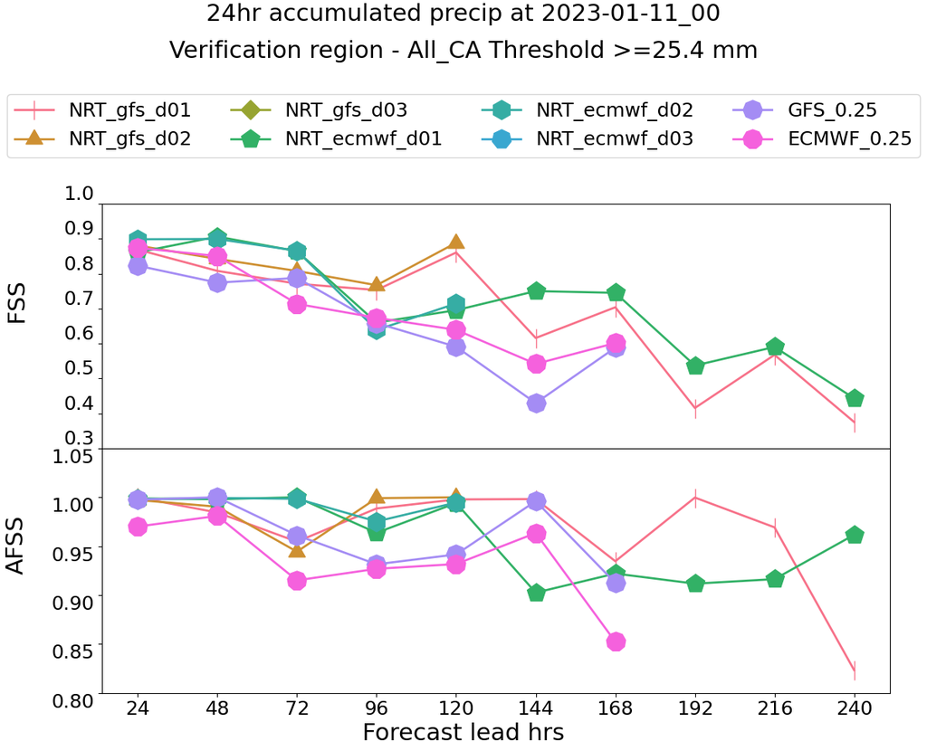

- Templates are designed for **multilead / multimodel / multidomain lineplots** for diagnostics for **particular valid dates**.
- **Axes scale** depending on the available forecast data, and plot configurations with **different lead hours together**.
- These templates are designed for **batch analysis of large hyper-parameter grids**.
- New tools and templates are under **continuous development**, with **research tools polished for re-use incrementally**.

## Conclusions

- This is an ongoing **research-to-operation project at CW3E**, to generate open source tools for both purposes.
- This **benefits from community interaction** on workflow and research tool development.
- However, this also **supports scientific objectives** for specific projects that are performed in **controlled information environments**.
- As such, this **infrastructure project** presents **opportunities for wider collaboration** where scientific dissemination may be restricted.
- This infrastructure talk highlights some of the **benefits and flexibility** of an **open source model** for infrastructure development.
- A late colleague of mine from when I was a postdoc in Norway, **Yongqi Gao**, liked to reference a proverb that is **applicable to open source development**:

> “If you want to go fast, go yourself. **If you want to go far, go together**”.

**Thank you!**